# UNICEF Global Awareness Report

Author

Sharon Fifo

```python
from google.colab import drive
drive.mount('/content/drive')
```

## Adolescents in Populations: A Global Perspective

The purpose of this report is to raise **public awareness** about the adolescent population trends across the globe.

```python
!pip install plotnine geopandas > /dev/null 2>&1

import pandas as pd
from plotnine import *
import geopandas as gpd

indicator1 = pd.read_csv('/content/drive/MyDrive/UNICEF_Project/unicef_indicator_1.csv')
metadata  = pd.read_csv('/content/drive/MyDrive/UNICEF_Project/unicef_metadata.csv')
```

```python
countries = ['Malta', 'Germany', 'Qatar', 'Hong Kong', 'Macao',
             'Malawi', 'Central African Republic', 'South Sudan', 'Uganda', 'Burundi']

filtered_data = indicator1[indicator1['country'].isin(countries)]
```

## Adolescent Population by Country

The bar chart below highlights the **adolescent population** in the selected 10 countries. These countries were chosen based on their adolescent population figures in recent years.

> **Key Insight:**  
> This visualization provides a clear comparison, allowing us to identify which countries have the highest number of adolescents.

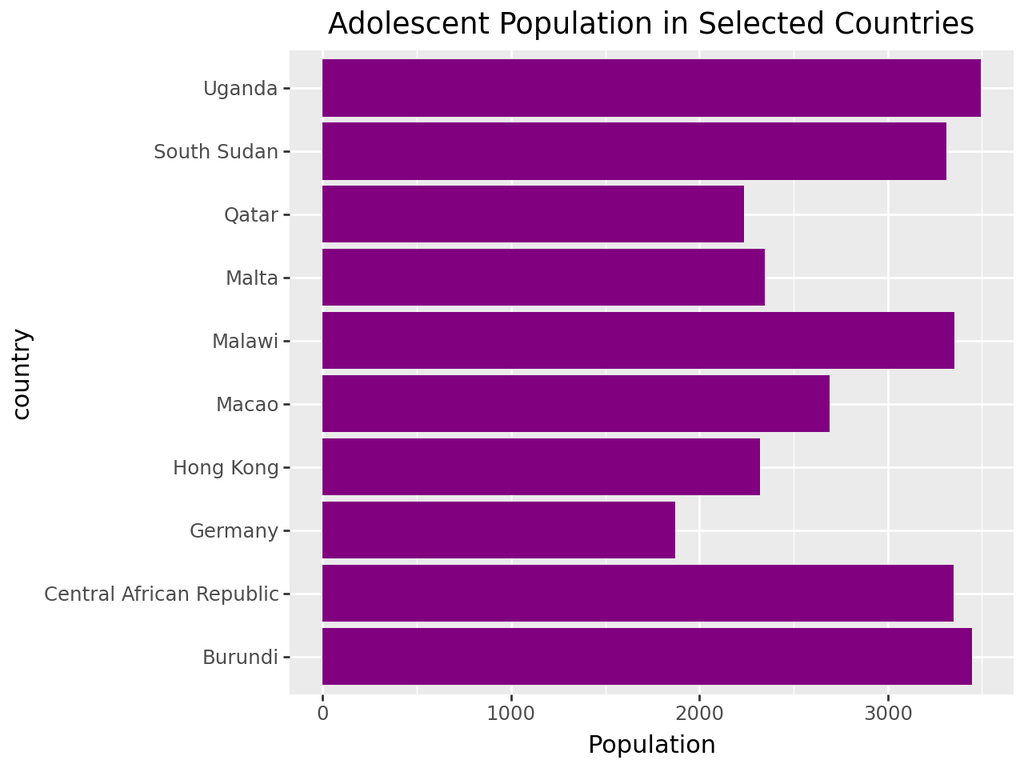

```python
(ggplot(filtered_data, aes(x='country', y='obs_value')) +
 geom_bar(stat='identity', fill='purple') +
 coord_flip() +
 labs(title='Adolescent Population in Selected Countries', y='Population', x='country'))
```

```python
filtered_data_new = indicator1[
    (indicator1['country'].isin(countries)) &
    (indicator1['sex'] == 'Total') &
    (indicator1['time_period'] == 2022)
]
```

```python
filtered_data_meta = metadata[
    (metadata['country'].isin(countries)) &
    (metadata['year'] == 2022)
]
```

```python
merged_data = pd.merge(
    filtered_data_new[['country', 'obs_value']],
    filtered_data_meta[['country', 'Life expectancy at birth, total (years)']],
    on='country',
    how='inner'
)
```

## Relationship Between Adolescent Population and Life Expectancy at Birth.

This scatter plot examines the relationship between the **adolescent population** (*obs_value*) and **life expectancy at birth** for the year *2022*. Each point represents a country, with a regression line indicating the overall trend.

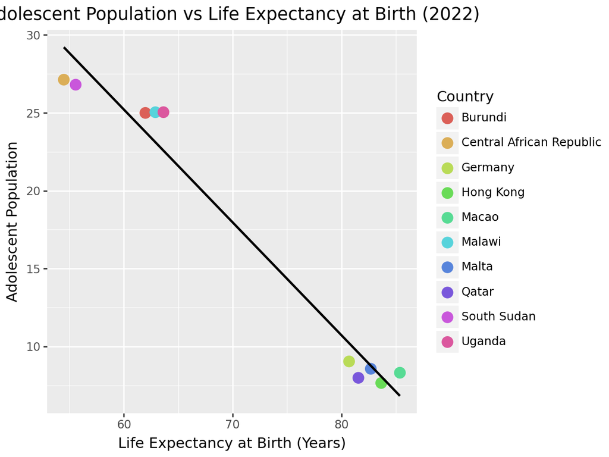

```python
(ggplot(merged_data, aes(x='Life expectancy at birth, total (years)', y='obs_value', color='country')) +
 geom_point(size=4) +
 geom_smooth(method='lm', color='black', se=False) +
 labs(title='Adolescent Population vs Life Expectancy at Birth (2022)',
      x='Life Expectancy at Birth (Years)',
      y='Adolescent Population',
      color='Country') +
 theme(legend_position='right'))
```

## Adolescent Population Trends.

Understanding how adolescent populations change over time is crucial for policy planning and resource allocation.

**Observation:** Some countries display steady growth, while others show fluctuations linked to social, economic, or health factors.

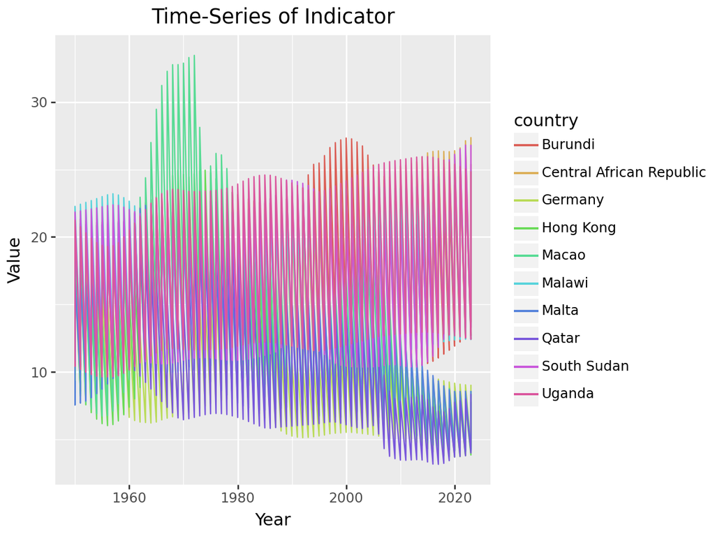

```python
filtered_data = indicator1[
    (indicator1['country'].isin(countries))
]

(ggplot(filtered_data, aes(x='time_period', y='obs_value', group='country', color='country')) +
 geom_line() +
 labs(title='Time-Series of Indicator', y='Value', x='Year'))
```

## Adolescent Population by Country

The world map below presents a **geographical overview** of adolescent populations in 2023. Countries are shaded based on the size of their adolescent population, with darker colors indicating higher values.

This map allows for: - A quick identification of regions with dense adolescent populations. - Visual comparison across continents.

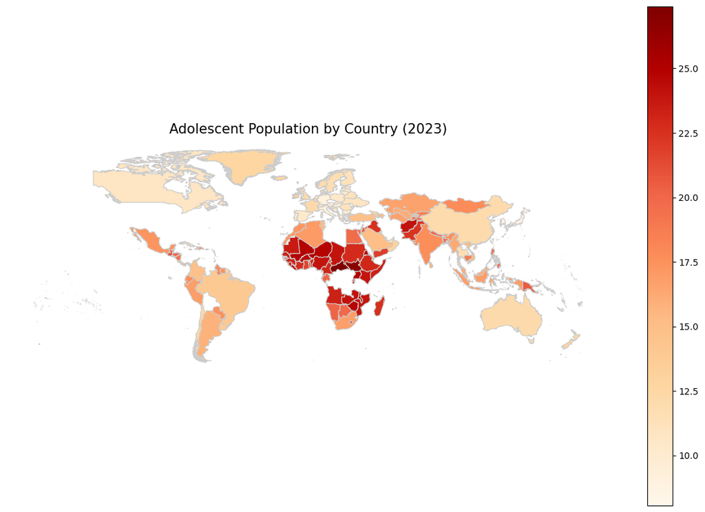

```python
import geopandas as gpd
import matplotlib.pyplot as plt

!wget -q https://raw.githubusercontent.com/datasets/geo-countries/master/data/countries.geojson -O countries.geojson

world = gpd.read_file('countries.geojson')

data_map = indicator1[
    (indicator1['time_period'] == 2023) &
    (indicator1['sex'] == 'Total')
][['country', 'obs_value']]

merged_map = world.merge(data_map, how='left', left_on='name', right_on='country')

fig, ax = plt.subplots(1, 1, figsize=(15, 10))

merged_map.plot(column='obs_value',
                cmap='OrRd',
                linewidth=0.8,
                ax=ax,
                edgecolor='0.8',
                legend=True)

ax.set_title('Adolescent Population by Country (2023)', fontsize=15)
ax.axis('off')

plt.show()
```

# Conclusion

This report provides a snapshot of global adolescent population trends and their relationship with key indicators like **life expectancy**.